# Neyman Orthogonality

Definitions, generalisations and estimators without a score

Jan Teichert-Kluge

# Neyman orthogonality

## Data, target and Riesz representer

We observe $n$ independent copies of $W=(Y,Z)$ with law $P$, where $Y$ is an outcome and $Z$ collects the regressors, and write $g_0(z)=\mathbb{E}[Y\mid Z=z]$ for the outcome regression and $\langle f,g\rangle=\mathbb{E}[f(Z)g(Z)]$ for the inner product of $L^2(P_Z)$.

The target is a linear functional $\theta_0=\theta(g_0)$ of the outcome regression, with $\theta(g)=\mathbb{E}[\nu(W;g)]$. When $\theta$ is mean-square continuous, by the Riesz representation theorem (Riesz 1907; Fréchet 1907) there is a unique $\alpha_0\in L^2(P_Z)$ with
$$\theta(g)=\langle\alpha_0,g\rangle\quad\text{for all }g\in L^2(P_Z),\qquad\text{hence}\qquad\theta(g_0+h)-\theta_0=\langle\alpha_0,h\rangle .$$
The representer $\alpha_0$ is therefore the derivative of the target with respect to the regression, and $\theta_0=\mathbb{E}[\alpha_0(Z)\,Y]$ (Chernozhukov, Newey, and Singh 2022, sec. 2).

| Target, with $Z=(D,X)$ | $\nu(W;g)$ | $\alpha_0(Z)$ |
| --- | --- | --- |
| average treatment effect (ATE), $D\in\{0,1\}$ | $g(1,X)-g(0,X)$ | $D/m_0(X)-(1-D)/\{1-m_0(X)\}$ |
| coefficient $\theta_0$ in $Y=\theta_0D+f_0(X)+\varepsilon$, $D=m_0(X)+V$ | $V\,g(Z)/\mathbb{E}[V^2]$ | $V/\mathbb{E}[V^2]$ |
| weighted average derivative, $D$ continuous | $\int\omega(u)\,\partial_dg(u,X)\,\mathrm{d}u$ | $-\omega'(D)/\varrho(D\mid X)$ |

For the ATE, $m_0(x)=P(D=1\mid X=x)$ is the propensity score, and the target is identified under consistency, unconfoundedness and overlap (Rosenbaum and Rubin 1983). The partially linear model is that of Robinson (1988), with $\mathbb{E}[\varepsilon\mid D,X]=0$ and $\mathbb{E}[V\mid X]=0$. For the derivative, $\omega$ is a known density and $\varrho(d\mid x)$ is the density of $D$ given $X$ (Chernozhukov, Newey, and Singh 2022, Table 1).

## Scores, moment conditions and cross-fitting

A score is a map $\psi(w;\theta,\eta)$ with a nuisance $\eta$ in a convex set $T$, and $M(\theta,\eta)=\mathbb{E}_P[\psi(W;\theta,\eta)]$ is its moment map. The score identifies $\theta_0$ if $M(\theta_0,\eta_0)=0$, this zero is unique, and the Jacobian $J_0=\partial_\theta M(\theta,\eta_0)|_{\theta=\theta_0}$ is non-singular. Examples are
$$\begin{aligned}
\psi_{\mathrm{DR}}(W;\theta,g,\alpha)&=\nu(W;g)-\theta+\alpha(Z)\{Y-g(Z)\},\\
\psi_{\mathrm{IV}}(W;\theta,f,m)&=\{Y-\theta D-f(X)\}\{D-m(X)\},\\
\psi_{\mathrm{PO}}(W;\theta,\ell,m)&=\{Y-\ell(X)-\theta(D-m(X))\}\{D-m(X)\},
\end{aligned}$$
where $\psi_{\mathrm{DR}}$ is the augmented inverse probability weighting (AIPW) score of any linear functional (J. M. Robins, Rotnitzky, and Zhao 1994; Chernozhukov, Newey, and Singh 2022, eq. 2.4), and $\psi_{\mathrm{IV}}$ and $\psi_{\mathrm{PO}}$ are the scores of the partially linear model with $\ell_0(X)=\mathbb{E}[Y\mid X]=\theta_0m_0(X)+f_0(X)$ (Chernozhukov et al. 2018, eqs. 4.3–4.4).

For the double machine learning (DML) estimator, we partition the sample into folds $I_1,\dots,I_K$, compute $\hat\eta_k$ from the observations outside $I_k$, and solve (Chernozhukov et al. 2018, Def. 3.2)
$$\frac1n\sum_{k=1}^K\sum_{i\in I_k}\psi(W_i;\theta,\hat\eta_k)=0 .$$

## Three-term decomposition

With $\mathbb{E}_{n,k}$ the average over fold $I_k$, $\mathbb{P}_n$ the average over the whole sample and $M(\theta_0,\eta_0)=0$, the average of the score splits as (Kennedy 2024)
$$\mathbb{E}_{n,k}\psi(W;\theta_0,\hat\eta_k)
=\underbrace{\mathbb{E}_{n,k}\psi(W;\theta_0,\eta_0)}_{T_1}
+\underbrace{(\mathbb{E}_{n,k}-P)\{\psi(\cdot;\theta_0,\hat\eta_k)-\psi(\cdot;\theta_0,\eta_0)\}}_{T_2}
+\underbrace{M(\theta_0,\hat\eta_k)}_{T_3},$$
and along the segment from $\eta_0$ to $\hat\eta_k$,
$$T_3=\partial_rM\big(\theta_0,\eta_0+r(\hat\eta_k-\eta_0)\big)\big|_{r=0}+\int_0^1(1-r)\,\partial_r^2M\big(\theta_0,\eta_0+r(\hat\eta_k-\eta_0)\big)\,\mathrm{d}r .$$

| Term | Property | Made negligible by |
| --- | --- | --- |
| $T_1$ | asymptotically normal | central limit theorem, which for the ATE requires overlap |
| $T_2$ | centred average of $n/K$ terms given $\hat\eta_k$ | cross-fitting with consistent $\hat\eta_k$, or stability of the nuisance estimator |
| $T_3$, first part | linear in $\hat\eta_k-\eta_0$ | Neyman orthogonality of the score |
| $T_3$, second part | quadratic in $\hat\eta_k-\eta_0$ | rates of convergence of $\hat\eta_k$ |

## Definition

Following Chernozhukov et al. (2018, sec. 2.1), let $\widetilde T=\{\eta-\eta_0:\eta\in T\}$ and define the Gateaux derivative map $\mathrm D_r:\widetilde T\to\mathbb{R}^{d_\theta}$ by
$$\mathrm D_r[\eta-\eta_0]=\partial_r\Big\{\mathbb{E}_P\big[\psi\big(W;\theta_0,\eta_0+r(\eta-\eta_0)\big)\big]\Big\},\qquad r\in[0,1).$$

Definition (Chernozhukov et al. 2018, Def. 2.1). The score $\psi$ obeys the Neyman orthogonality condition at $(\theta_0,\eta_0)$ with respect to the nuisance realisation set $\mathcal T_N\subset T$ if $M(\theta_0,\eta_0)=0$, the map $\mathrm D_r[\eta-\eta_0]$ exists for all $r\in[0,1)$ and $\eta\in\mathcal T_N$, and
$$\partial_\eta\mathbb{E}_P\psi(W;\theta_0,\eta_0)[\eta-\eta_0]:=\mathrm D_0[\eta-\eta_0]=0\qquad\text{for all }\eta\in\mathcal T_N .$$

- The derivative is taken at the truth with the target held at $\theta_0$. It is the derivative of the moment map, which equals $\mathbb{E}_P\partial_\eta\psi$ only when differentiation under the integral is allowed.
- The set $\mathcal T_N$ contains the nuisance estimates, where $N$ is the sample size, and a smaller set imposes a weaker condition. The condition therefore depends on the law $P$ and on the set $\mathcal T_N$ as well as on the score.
- The score obeys the $\lambda_N$ near-orthogonality condition if $\|\mathrm D_0[\eta-\eta_0]\|\le\lambda_N=o(N^{-1/2})$ for all $\eta\in\mathcal T_N$ (Chernozhukov et al. 2018, Def. 2.2), which arises when the parameter that orthogonalises the score is defined by a regularised problem.

## Moment maps along a nuisance direction

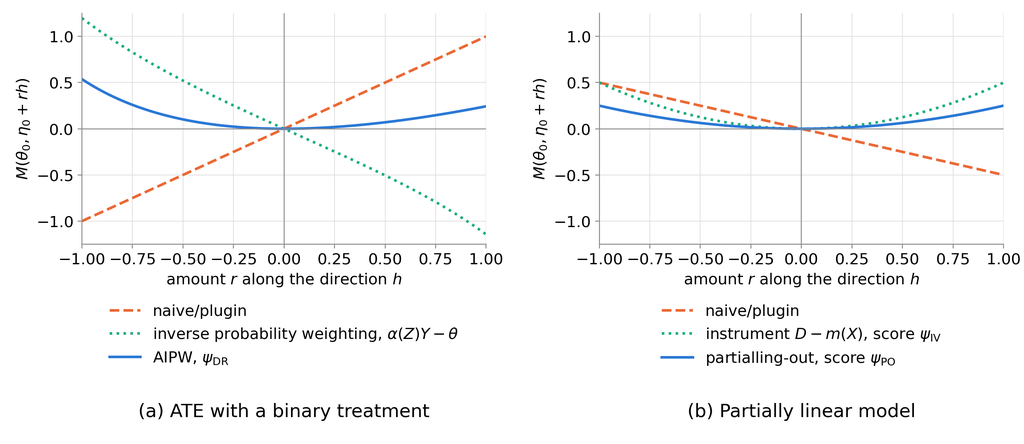

With $X$ uniform on $[0,1]$ and $\theta_0=1$, panel (a) uses $m_0(x)=0.25+0.5x$, $g_0(d,x)=d+2x$ and the direction $(g,m)=(g_0+rd,\,m_0+0.15r)$, and panel (b) uses $m_0(x)=x$, $f_0(x)=x^2$ and the directions $f_0+r$, $\ell_0+r$ and $m_0+0.5r$. The slope at $r=0$ is $\mathrm D_0[h]$, which vanishes for the AIPW score and for both scores of the partially linear model.

## Construction of orthogonal scores

Correction by the Riesz representer. For a fixed $A\in L^2(P_Z)$, the score $\nu(W;g)-\theta+A(Z)\{Y-g(Z)\}$ has the derivative $\mathrm D_0[h]=\mathbb{E}[\nu(W;h)]-\mathbb{E}[A(Z)h(Z)]=\langle\alpha_0-A,\,h\rangle$ in a direction $h$ of $g$. It is orthogonal in $g$ for a dense set of directions exactly when $A=\alpha_0$, so the correction term of an orthogonal score of a linear functional is the Riesz representer times the residual. With $\alpha$ as a second nuisance, the score is orthogonal in $\alpha$ because $\mathbb{E}[Y-g_0(Z)\mid Z]=0$.

Orthogonal instruments. In the partially linear model, the moment $\mathbb{E}[A(D,X)\{Y-\theta_0D-f(X)\}]$ has the derivative $-\mathbb{E}\big[\mathbb{E}[A\mid X]\,h(X)\big]$ in a direction $h(X)$ of $f$, so it is orthogonal in $f$ exactly when $\mathbb{E}[A\mid X]=0$. Every instrument $\{D-m_0(X)\}k(X)$ satisfies this condition, so orthogonal scores are not unique, and the choice of $k$ affects the efficiency (Chernozhukov et al. 2018, sec. 2.2.4).

Projection on the nuisance scores. In a regular parametric model with scores $s_\theta$ and $s_\eta$ and information matrix with blocks $I_{\theta\eta}$ and $I_{\eta\eta}$, let $\mathbb{E}_{\theta_0,\eta}\psi(W;\theta_0,\eta)=0$ for all $\eta$. Differentiating in $\eta$ gives $\partial_\eta M(\theta_0,\eta_0)=-\mathbb{E}[\psi_0s_\eta^\top]$, where $\psi_0=\psi(\cdot;\theta_0,\eta_0)$. The residual score of Neyman (1959, 1979),
$$\psi=s_\theta-I_{\theta\eta}I_{\eta\eta}^{-1}s_\eta ,$$
is uncorrelated with $s_\eta$ and therefore orthogonal. Chernozhukov et al. (2018, sec. 2.2) construct orthogonal scores in likelihood and moment problems by projecting a score off the nuisance directions, and the orthogonalising matrix becomes a further nuisance.

## Double robustness and the mixed bias property

Let the nuisance be a pair $(g,\alpha)\in\mathcal T_g\times\mathcal T_\alpha$. The score is doubly robust if $M(\theta_0,g,\alpha_0)=M(\theta_0,g_0,\alpha)=0$ for all $g$ and $\alpha$, and it has the mixed bias property if $M(\theta_0,g,\alpha)=\mathbb{E}[S(W)\,(g-g_0)(Z)\,(\alpha-\alpha_0)(Z)]$ for all $(g,\alpha)$ and a known function $S$ (A. Rotnitzky, Smucler, and Robins 2021). The AIPW score has the mixed bias property with $S=-1$ (Chernozhukov, Newey, and Singh 2022, eq. 2.5),
$$M(\theta_0,g,\alpha)=-\langle g-g_0,\,\alpha-\alpha_0\rangle\qquad\text{for every pair }(g,\alpha).$$

Proposition. Let $T=\mathcal T_g\times\mathcal T_\alpha$ be a product of convex sets, let $\mathcal T_N=T$, and let $\mathrm D_0$ be linear. Then the following hold.

1. The mixed bias property implies double robustness, and double robustness implies orthogonality.
2. If $M(\theta_0,g_0,\alpha)=0$ for every $\alpha$, the score is doubly robust exactly when it is orthogonal and $g\mapsto M(\theta_0,g,\alpha_0)$ is affine (Chernozhukov, Escanciano, et al. 2022, Thm. 4).
3. Orthogonality does not imply double robustness. In the partially linear model,
   $$M_{\mathrm{PO}}(\theta_0,\ell,m)=\langle\ell-\ell_0,\,m-m_0\rangle-\theta_0\|m-m_0\|^2,\qquad M_{\mathrm{IV}}(\theta_0,f,m)=\langle f-f_0,\,m-m_0\rangle,$$
   so both scores are orthogonal, and for $\theta_0\neq0$ only $\psi_{\mathrm{IV}}$ is doubly robust.

Since $\ell_0=\theta_0m_0+f_0$ contains $m_0$, an error in $m$ also enters through $\ell$. The choice of the nuisance that is called the outcome model matters for double robustness and does not matter for orthogonality.

## Properties and limits of orthogonal scores

Properties

- The nuisance error enters the bias term $T_3$ only through second-order terms, which are $o_P(n^{-1/2})$ when $\|\hat\eta_k-\eta_0\|=o_P(n^{-1/4})$ in $L^2(P)$, or, for scores with the mixed bias property, when $\|\hat g-g_0\|\,\|\hat\alpha-\alpha_0\|=o_P(n^{-1/2})$, so any learner with these rates can estimate the nuisance.
- With cross-fitting and these rates, the DML estimator is asymptotically linear with influence function $-J_0^{-1}\psi_0$, and Wald intervals with a plug-in variance estimator are valid uniformly over models in which the rates hold uniformly (Chernozhukov et al. 2018, Thm. 3.1, Thm. 3.2 and Cor. 3.1).
- Under the mixed bias property the bias formula holds for every nuisance pair, so nuisance errors from any source enter through one inner product.

Limits

- Orthogonality removes only the first-order part of $T_3$, and nuisance errors that do not shrink with $n$ violate the rate conditions.
- Overlap is needed for $\alpha_0\in L^2(P_Z)$ and for a bounded $\hat\alpha$, and trimming changes the estimand.
- Identification of a causal target requires assumptions about the process that generates the data, which do not depend on the score.
- The definition applies to estimators that solve an estimating equation.

# Generalisations of Neyman orthogonality

## Approaches by term of the decomposition

| Approach | Term | Representative references |
| --- | --- | --- |
| correction of the score | first part of $T_3$ | (Newey 1994; Chernozhukov et al. 2018; Chernozhukov, Escanciano, et al. 2022) |
| automatic or numerical correction | first part of $T_3$ | (Chernozhukov, Newey, and Singh 2022; Chernozhukov, Newey, Quintas-Martı́nez, et al. 2022; Carone, Luedtke, and Laan 2019; Ichimura and Newey 2022) |
| fit that solves the orthogonal equation | first part of $T_3$ | (Scharfstein, Rotnitzky, and Robins 1999; M. J. van der Laan and Rubin 2006; Bruns-Smith et al. 2026) |
| balancing and minimax weights | first part of $T_3$ | (Zubizarreta 2015; Kallus 2020; Hirshberg and Wager 2021) |
| prior invariant along the least-favourable direction | first part of $T_3$ | (Castillo and Rousseau 2015; Ray and van der Vaart 2020; Breunig, Liu, and Yu 2025; Melnychuk, Javurek, and Feuerriegel 2026) |
| higher-order orthogonality and influence functions | higher-order parts of $T_3$ | (Mackey, Syrgkanis, and Zadik 2018; J. Robins et al. 2008; J. M. Robins et al. 2017) |
| cross-fitting, stability of the nuisance estimator | $T_2$ | (Chernozhukov et al. 2018; Chen, Syrgkanis, and Austern 2022) |
| calibration and further targeting | second part of $T_3$, one slow nuisance | (Benkeser et al. 2017; L. van der Laan, Luedtke, and Carone 2024) |

## Automatic debiased machine learning

The correction term of an orthogonal score of a linear functional contains the Riesz representer, which minimises the Riesz loss
$$\mathbb{E}\big[\alpha(Z)^2-2\nu(W;\alpha)\big]=\|\alpha-\alpha_0\|^2-\|\alpha_0\|^2 .$$
The loss can be evaluated without a formula for $\alpha_0$ when $\nu$ does not depend on $P$, as for the ATE, and minimising an empirical version of it over a class of functions is called Riesz regression (Chernozhukov et al. 2021).

- Chernozhukov, Newey, and Singh (2022) minimise a Lasso version of the Riesz loss over linear $\alpha$, use the fit in the cross-fitted AIPW score of any mean-square continuous linear functional, and call the method automatic debiased machine learning.
- RieszNet learns $g$ and $\alpha$ with a neural network that shares its layers between the two, and ForestRiesz learns $\alpha$ with a random forest (Chernozhukov, Newey, Quintas-Martı́nez, et al. 2022).
- Chernozhukov et al. (2026) give a textbook account of automatic debiased machine learning, and L. van der Laan et al. (2025) extend it to smooth functionals of M-estimands, which are population risk minimisers such as counterfactual regressions, survival functions and conditional average treatment effects, using the gradient and Hessian of the loss in place of an analytic influence function.
- For targets without a known form of the influence function, the correction can be computed numerically, by finite differences of $P\mapsto\theta(P)$ at an estimate of $P$ perturbed toward a smoothed point mass (Carone, Luedtke, and Laan 2019; Jordan, Wang, and Zhou 2022), or as the derivative of the limit of the estimator along contamination paths (Ichimura and Newey 2022).

## Orthogonality without an explicit correction

- Targeting. The clever covariate (Scharfstein, Rotnitzky, and Robins 1999; Bang and Robins 2005) and targeted maximum likelihood (M. J. van der Laan and Rubin 2006; M. J. van der Laan and Rose 2011) add $\hat\alpha$ to the outcome fit so that $\mathbb{P}_n[\hat\alpha\{Y-\hat g\}]=0$, and the plug-in at the modified fit equals the corrected estimator.
- Sieves. Least squares on a closed subspace $\mathcal S$, with projection $\mathsf P_{\mathcal S}$ and $\mathsf M_{\mathcal S}=I-\mathsf P_{\mathcal S}$, solves the orthogonal equation for $\mathsf P_{\mathcal S}\alpha_0$, and the plug-in bias is $-\langle\mathsf M_{\mathcal S}\alpha_0,\mathsf M_{\mathcal S}g_0\rangle$ (Chernozhukov, Newey, and Singh 2022, eq. 2.6). Sieve plug-ins can be efficient for smooth functionals (Newey 1994; Shen 1997).
- Balancing weights. Weighting estimators $n^{-1}\sum_iw_iY_i$ can be designed so that the weights balance a class of outcome functions, exactly or up to a bound on the worst-case imbalance (Zubizarreta 2015; Kallus 2020; Hirshberg and Wager 2021). When the outcome and weighting models are linear in the same basis, augmented balancing weights are equivalent to a single linear regression (Bruns-Smith et al. 2026).
- Priors. The no-bias condition of a semiparametric Bernstein–von Mises theorem (Castillo and Rousseau 2015) holds when the prior is approximately invariant under shifts of order $n^{-1/2}$ along the least-favourable direction, which for the ATE is proportional to the Riesz representer when $\operatorname{Var}(Y\mid Z)$ is constant (Ray and Szabó 2019; Breunig, Liu, and Yu 2025). Priors that depend on an estimated propensity score achieve this invariance (Ray and van der Vaart 2020). Javurek et al. (2026) put a prior on the causal target and update it with a loss that identifies the target in a generalised posterior, which for Neyman-orthogonal losses converges to its oracle counterpart. Other approaches correct the posterior (Breunig, Liu, and Yu 2025; Yiu et al. 2025) or change the outcome model, by a reparametrisation (P. R. Hahn et al. 2018) or with the estimated propensity score as a covariate (P. R. Hahn, Murray, and Carvalho 2020).

## Learned representations and in-context nuisance learners

- Neural networks for treatment effects learn representations that predict both the treatment and the outcome, as DragonNet with its targeted regularisation (Shi, Blei, and Veitch 2019) and the adapted text embeddings of Veitch, Sridhar, and Blei (2020).
- Melnychuk, Frauen, et al. (2026) argue that end-to-end representation learning lacks the quasi-oracle efficiency of Neyman-orthogonal learners, and they propose OR-learners, which combine learned representations with Neyman-orthogonal learners of causal quantities.
- TabPFN, a prior-data fitted network (PFN) for tabular prediction (Hollmann et al. 2025), has been used as nuisance learner in meta-learners for heterogeneous effects (Q. Zhang et al. 2025) and in the DoubleML software (Bach et al. 2024).
- Y. Wang, Secrest, and Tchakoute (2026) add a propensity output to CausalPFN, trained jointly with its outcome model, and build AIPW and TMLE estimators on it. These estimators remain stable as confounding grows, whereas the Bayesian plug-in estimate of CausalPFN degrades.
- Optimal covariate balancing is dual to a regularised self-attention, and J. Zhang et al. (2024) learn balancing weights across data sets.
- For a simplified transformer, the variance of a PFN vanishes as $n$ grows while its bias need not (Nagler 2023).

## Causal prior-data fitted networks

- Causal PFNs, such as Do-PFN (Robertson et al. 2025), CausalPFN (Balazadeh et al. 2025) and CausalFM (Ma et al. 2026), return effect estimates from the data set in context, without an orthogonal score.
- In simulations based on clinical data, the estimates of CausalPFN were biased and its credible intervals covered poorly (Mourão et al. 2026).
- H. Wang et al. (2026) prove that one structural causal model induces an exponentially large space of interventional distributions, so that pretraining leaves part of them uncovered, which leads to posterior inconsistency and estimation bias, and they propose fine-tuning for specific interventions.
- Melnychuk, Balazadeh, et al. (2026) show that PFNs used as Bayesian ATE estimators have a confounding bias induced by the prior, which they identify with regularisation-induced confounding, the bias of a regularised outcome regression that shrinks the coefficients of covariates that also predict the treatment (P. R. Hahn et al. 2018), and they correct it by a one-step correction of martingale posteriors of TabPFN.
- Z. Zhang (2026) pretrains causal tabular models on the labels $\theta(P)+\mathbb{P}_n\varphi_P$, the ATE plus the fluctuation term of its EIF, and derives the coverage of Wald intervals for the frozen network.

Neyman orthogonality is defined for scores, and causal PFNs that return the effect directly have none.

## Debiased prior-data fitted networks

Melnychuk, Javurek, and Feuerriegel (2026) train a PFN with the log loss on the target $\theta_\xi$ of data-generating processes $\xi$ drawn from a prior $\Pi$. They call the network idealised when it returns the posterior of $\theta_\xi$ exactly, and they study this posterior under data from a fixed law $P$ for general targets with an EIF, including the ATE.

- Without a correction, the $L^2$ concentration error of the target posterior is at most the posterior average of the nuisance error plus a second-order remainder, and a worst-case posterior inherits the nuisance rate (Melnychuk, Javurek, and Feuerriegel 2026, Thm. 1).
- Label correction. The network is trained on the labels $\theta_\xi+\sum_i\varpi_i\varphi_\xi(W_i)$, with the EIF $\varphi_\xi$ under $\xi$ and Bayesian bootstrap weights $(\varpi_1,\dots,\varpi_n)\sim\mathrm{Dirichlet}(1,\dots,1)$ drawn independently of $\xi$ and $\mathcal D_n$, so that the one-step posterior correction of Yiu et al. (2025) is applied in pretraining (Melnychuk, Javurek, and Feuerriegel 2026, Eq. 12).
- Prior correction. Each process $\xi$ is perturbed along a least-favourable submodel, a one-dimensional submodel through $\xi$ whose score is $\varphi_\xi$, with a coefficient $\kappa\sim N(0,\sigma_n^2)$ and $n\sigma_n^2\to\infty$, which extends the prior correction of Ray and van der Vaart (2020; Melnychuk, Javurek, and Feuerriegel 2026, Eq. 15). For the ATE with Gaussian noise of unit variance, the outcome regression $g_\xi$ of $\xi$ is replaced by $g_\xi+\kappa\alpha_\xi$, with the Riesz representer $\alpha_\xi$ of the ATE under $\xi$, and the density of $X$ is reweighted with the same $\kappa$ (App. F.2.1).
- With either correction and a stochastically equicontinuous posterior, the posterior of the idealised network concentrates at the rate $n^{-1/2}$ plus the remainder (Thm. 2). When the remainder is $o_P(n^{-1/2})$, a Bernstein–von Mises theorem with the efficient variance holds under regularity conditions (Thm. 3). When the mean square of the remainder is bounded uniformly over a class of laws supported by the prior, the worst-case risk of the posterior mean over this class is of order $n^{-1}$ plus this bound, the minimax rate when a matching lower bound holds (Thm. 4).
- In ATE experiments, the training prior draws the propensity score independently of the outcome regressions, and an evaluation prior has more observed confounding. Under the evaluation prior, the authors report that both corrected networks often have a smaller $L^2$ risk than the network without a correction for $n\ge1024$ with 5 covariates and $n\ge2048$ with 10, and the total variation distance of all networks to the efficient normal approximation grows with $n$ (Sec. 5).

# Research question and contribution

## Project question and motivation

Motivation. Causal PFNs return an effect estimate in one forward pass, but they have no score, so Neyman orthogonality cannot be checked for them. In simulations based on clinical data, CausalPFN was biased and its credible intervals covered poorly (Mourão et al. 2026). The guarantees of Melnychuk, Javurek, and Feuerriegel (2026) hold for the idealised network, and their theory sets the amortisation error of a trained network aside.

Main question. When is an estimator without a score, in particular a trained in-context learner, first-order insensitive to errors in the outcome regression, and how can this be checked from the data and the trained network alone?

1. Which property of an estimator takes the place of Neyman orthogonality, how is it related to regularity and to orthogonal scores, and which shifts beyond those of the outcome regression does it have to cover?
2. Do the implicit weights $w_i=n\,\partial\hat\theta/\partial Y_i$ of a trained network give a diagnostic of this property, and under which conditions does a test based on it have a known level?
3. Which training targets and priors make the Bayes rule of an in-context learner first-order insensitive?
4. Are trained networks first-order insensitive when they use the corrections of Melnychuk, Javurek, and Feuerriegel (2026), or in-context nuisances with cross-fitting and an AIPW layer?

# First-order insensitivity and implicit weights

## Outcome shifts and first-order insensitivity

Idea. A causal PFN learns the outcome regression $g_0$ from the data set and returns an estimate $\hat\theta$, but it has no score whose orthogonality could be checked. We therefore ask how the mean of the estimate responds when the outcome regression changes. When the true effect changes by some amount, the mean of a good estimate changes by the same amount, and any difference is a bias caused by errors in learning $g_0$.

Outcome shifts. For a direction $h\in L^2(P_Z)$ and $\delta\in\mathbb{R}$, let $P_{\delta h}$ be the law of $(Y+\delta h(Z),Z)$ under $P$, so that every outcome is moved by $\delta h(Z)$. Under $P_{\delta h}$ the outcome regression is $g_0+\delta h$ and the target is $\theta_0+\delta\langle\alpha_0,h\rangle$, and the bias of $\hat\theta$ along the shift is $b_n(\delta;h)=\mathbb{E}_{\delta h}[\hat\theta]-\theta(P_{\delta h})$.

Definition. The estimator is first-order insensitive to the outcome regression in the direction $h$ at $P$ and sample size $n$ if $\partial_\delta b_n(0;h)=0$, and over a class $\mathcal H\subset L^2(P_Z)$ if this holds for every $h\in\mathcal H$. We call $\partial_\delta b_n(0;h)$ the sensitivity in the direction $h$. A sensitivity of zero means that, to first order, the mean of the estimate moves one for one with the target when the regression moves along $h$.

Example. For the ATE and $h(d,x)=d$, the shift adds $\delta$ to every treated outcome, so the ATE increases by $\delta$. A plug-in estimate whose fitted effect is shrunk toward zero increases by less than $\delta$, and its sensitivity in this direction is negative.

- The definition uses only the map from data sets to estimates, so it applies to posterior means and to trained networks.
- Neyman orthogonality requires that a moment condition does not respond to first-order errors in a nuisance, and first-order insensitivity requires the same of the mean of the estimate along shifts of the outcome regression.
- As $n\to\infty$, the condition is the derivative part of local asymptotic unbiasedness (Hirano and Porter 2012).

## Implicit weights

Definition. For an estimator that is differentiable in the outcomes, the implicit weights are $w_i=n\,\partial\hat\theta/\partial Y_i$, the change of the estimate per unit change of the outcome of row $i$, multiplied by $n$. A network returns all $n$ weights in one backward pass. For a linear estimator $\hat\theta=n^{-1}\sum_iw_iY_i$ the weights are its coefficients, for example $w_i=\hat\alpha(Z_i)$ for an inverse propensity weighting estimator, and for posterior means they are the locally equivalent weights of Giordano et al. (2026).

Sensitivity and weights. Moving every outcome by $\delta h(Z_i)$ moves the estimate by approximately $\delta\,n^{-1}\sum_iw_ih(Z_i)$, while the target moves by $\delta\langle\alpha_0,h\rangle$.
$$\partial_\delta b_n(0;h)=\mathbb{E}_P\Big[\frac1n\sum_{i=1}^nw_i\,h(Z_i)\Big]-\langle\alpha_0,h\rangle .$$
The estimator is first-order insensitive in the direction $h$ exactly when its weights balance $h$ in expectation in the sense of this equation. For the ATE, $\langle\alpha_0,h\rangle=\mathbb{E}[h(1,X)-h(0,X)]$, and the weights of an insensitive estimator act on $h$ in expectation like the inverse propensity weights $\alpha_0(Z)=D/m_0(X)-(1-D)/\{1-m_0(X)\}$.

Sample imbalance. The sample imbalance $\hat\Delta(h)=n^{-1}\sum_iw_ih(Z_i)-n^{-1}\sum_i\nu(W_i;h)$ has the sensitivity as its mean when $\nu$ does not depend on $P$, as for the ATE, and it needs neither $g_0$ nor $\alpha_0$. In simulations, where $\alpha_0$ is known, we report $S_\alpha=\mathbb{E}[\hat\Delta(\alpha_0)]/\|\alpha_0\|^2$. A value $S_\alpha=0$ means that the mean of the estimate follows a shift of the target along $\alpha_0$ fully, and $S_\alpha=-0.2$ means that it follows only 80% of it.

## Estimators that are equivariant in the outcomes

Why this class matters. The implicit weights are derivatives, so in general they describe only the response of the estimate to small changes of the outcomes. For estimators that are equivariant in the outcomes they describe the estimate itself, which is then a weighted mean of the outcomes, and its bias is the sum of an imbalance of the weights and a remainder. Our networks belong to this class, because they standardise the outcomes of the context with its mean and standard deviation and report the effect on the original scale, and so do least squares and AIPW with equivariant nuisance estimators.

Equivariance. The estimator is equivariant in the outcomes if $\hat\theta(Z_{1:n},a+bY_{1:n})=a\,\kappa_n(Z_{1:n})+b\,\hat\theta(Z_{1:n},Y_{1:n})$ for all $a\in\mathbb{R}$ and $b>0$. Adding $a$ to every outcome then moves the estimate by $a\kappa_n$, and multiplying every outcome by $b$ multiplies the estimate by $b$. For the ATE, $\kappa_n=0$.

Weighting representation. By Euler’s theorem for homogeneous functions, an equivariant estimator that is differentiable in the outcomes satisfies $\hat\theta=n^{-1}\sum_iw_iY_i$ at every data set, although its weights depend on the outcomes. With $\varepsilon_i=Y_i-g_0(Z_i)$, the error splits into the three terms that Armstrong and Kolesár (2021, secs. 2.2, 3.2) give for linear estimators,
$$\hat\theta-\theta_0=\underbrace{\hat\Delta(g_0)}_{\text{imbalance along }g_0}+\underbrace{\Big\{\frac1n\sum_{i=1}^n\nu(W_i;g_0)-\theta_0\Big\}}_{\text{mean zero}}+\underbrace{\frac1n\sum_{i=1}^nw_i\varepsilon_i}_{\text{noise term}} .$$

- For every law of the noise, the bias is the sensitivity along the true regression $g_0$ plus the mean of the noise term. An equivariant estimator that is first-order insensitive along $g_0$ is therefore unbiased up to the noise term.

## A diagnostic from one data set

Goal. In an application we have one data set and the trained network, but neither $g_0$ nor $\alpha_0$. From these alone we want to test whether the network is first-order insensitive in a direction $\hat h$, that is, whether $\mathbb{E}[\hat\Delta(\hat h)]=0$.

Imbalance. For the ATE, the imbalance along $\hat h$ is the weighted mean of $\hat h$ minus the change of the ATE along $\hat h$,
$$\hat\Delta(\hat h)=\frac1n\sum_{i=1}^nw_i\,\hat h(D_i,X_i)-\frac1n\sum_{i=1}^n\{\hat h(1,X_i)-\hat h(0,X_i)\},$$
and it needs only the weights of the network and the direction.

Direction. The test is informative along directions in which the network is sensitive. Since $S_\alpha$ depends mostly on the response of the estimate where the overlap is weak and $|\alpha_0|$ is large, we use a direction close to $\alpha_0$, estimated on a separate part of the data. The last $n_s=\max(50,\lceil0.2n\rceil)$ rows form a split, on which we fit a propensity score $\hat m$, and the direction is the clipped representer
$$\hat\alpha_{0.3}(d,x)=\frac{d}{\hat m_{0.3}(x)}-\frac{1-d}{1-\hat m_{0.3}(x)},\qquad \hat m_{0.3}=\min\{\max(\hat m,0.3),0.7\}.$$
The network is run on the other $n_e=n-n_s$ rows, the evaluation rows.

- The direction is fitted on the split, so it is fixed given the split, and the imbalance on the evaluation rows has the sensitivity along $\hat h$ as its mean.
- Without the clipping, rows with propensity scores close to 0 or 1 receive very large inverse propensities and dominate the imbalance.
- The candidates for $\hat m$ are logistic regression, gradient boosting and the propensity head of the network, and we take the one whose representer has the smallest Riesz loss on the split.

# Experiments with trained networks

## Networks, priors and truths

Networks. We train small causal PFNs with the backbone of nanoTabPFN (Pfefferle et al. 2025), with about 0.2M parameters and a decoder for the conditional average treatment effect (CATE), for 3,000 steps in four variants of the loss and with three seeds each. The plug-in estimate of the ATE is the mean of the predicted CATEs with the whole sample as context. In the first variant the network has no nuisance heads and is trained on the CATE and the ATE, in the second its heads for $m$, $g$ and $\alpha$ are supervised with the exact nuisances of the simulator, in the third the loss on the ATE is also taken through an AIPW layer with cross-fitting in context, and in the fourth the losses of the heads are annealed to zero by the middle of training.

Training prior. A task has a binary treatment, one to five covariates and 50 to 250 rows, and its propensity score, baseline and effect are random linear functions, random networks, Gaussian processes or sums of trees. The baseline is drawn with a correlation $\rho$ with the logit of the propensity score, where $|\rho|\le0.9$, so the treatment and outcome mechanisms are dependent.

Truths. A truth is one data-generating process, drawn from the training prior or from a prior with strong confounding and weak overlap, in which $|\rho|\in[0.7,0.9]$ and the scale of the propensity logit lies in $[1.5,2.5]$, both inside the ranges of the training prior. We use 16 truths per prior with 32 data sets each at $n=100$, 250 and 500, and for the diagnostic also 40 to 128 new truths per prior, drawn with another seed, with 32 data sets each at $n=250$ and 500. Outcomes are in units of the standard deviation of $Y$ under the truth.

Released networks. CausalPFN (Balazadeh et al. 2025), CausalFM (Ma et al. 2026) and Do-PFN (Robertson et al. 2025) are evaluated at the 16 truths per prior on 8 data sets each. We use them as black boxes, so their sensitivities are central finite differences of the estimate along the direction.

## Sensitivity of trained networks along the Riesz representer

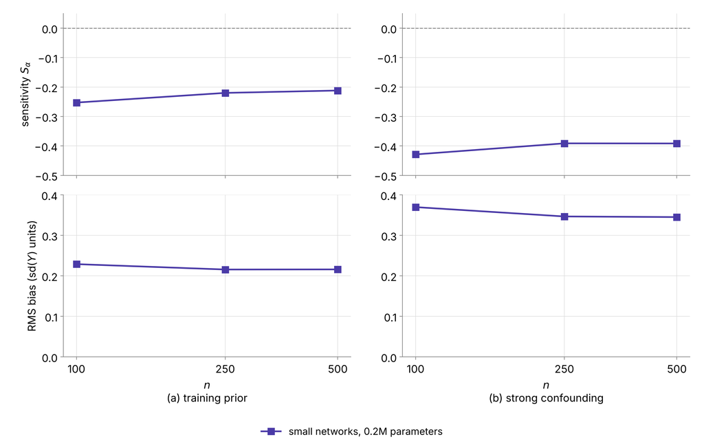

## Released causal PFNs

Under a prior in which the treatment mechanism is drawn independently of the covariate and outcome mechanisms, the posterior mean of the ATE does not involve the likelihood of the treatments, so it is a Bayesian outcome regression with the uncorrected term in its error. The priors of CausalPFN and CausalFM have this form.

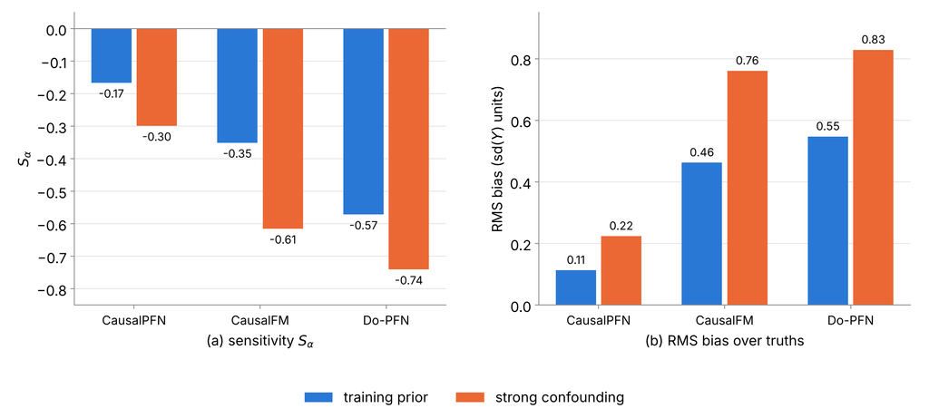

The bars are for $n=500$ with 8 data sets per truth at the 16 truths per prior. CausalPFN follows 83% of a shift along $\alpha_0$ on the training prior and 70% under strong confounding, with an RMS bias of 0.11 and 0.22, and CausalFM and Do-PFN follow only 26% to 65% of such a shift, with an RMS bias of 0.46 to 0.83. At the same truths, $S_\alpha$ is $-0.21$ and $-0.39$ for our small networks.

## Noise term and corrections

Correction. Subtracting the imbalance along an outcome regression $\hat g$ fitted on an independent sample gives $\hat\theta^{\mathrm c}=\hat\theta-\hat\Delta(\hat g)$, a plug-in estimator corrected with the implicit weights. For an estimator invariant under permutations of the observations, with $\omega_n(z)=\mathbb{E}[w_1\mid Z_1=z]$, the bias of $\hat\theta^{\mathrm c}$ is $\langle\omega_n-\alpha_0,\,g_0-\hat g\rangle$ plus the noise term, a product of two errors as in the mixed bias property of AIPW.

Small networks. For the small networks, the bias is almost entirely the imbalance along $g_0$, with correlations of 0.98 to 0.99 over truths, so by the decomposition for equivariant estimators the noise term is small. Subtracting the imbalance along an outcome regression fitted by gradient boosting out of fold, $\hat\theta^{\mathrm c}=\hat\theta-\hat\Delta(\hat g)$, lowers the RMS bias at $n=500$ from 0.215 to 0.091 on the training prior and from 0.344 to 0.164 under strong confounding.

- The correction uses only the implicit weights of the network and an outcome regression fitted on other rows.

## Status and next steps

| Part | Status |
| --- | --- |
| First-order insensitivity, implicit weights, equivariant estimators and the corrections | propositions in the draft of the paper, working on proofs |
| Block test of zero sensitivity | level at most nominal for normal block values, and with the transformation of Hall rejection rates under zero sensitivity of at most 5.3% on each prior on new truths for the small networks |
| Small networks | evaluated at $n\le500$ |
| Released networks CausalPFN, CausalFM and Do-PFN | evaluated at the 16 truths per prior |

Next steps. We evaluate larger networks, compute the power of the test up to $n=2{,}000$ and evaluate the corrections. The target venue of the paper is ICML 2027, with the ATE in the main text, and CausalPFN is evaluated on IHDP (Hill 2011) and on the LaLonde PSID data (LaLonde 1986; Dehejia and Wahba 1999) in the version of RealCause (Neal, Huang, and Raghupathi 2020), against tuned DoubleML (Bach et al. 2024) and AIPW with TabPFN nuisances (Hollmann et al. 2025).

## Questions for discussion

1. Which fixed directions of a sensitivity, such as the constant shift $h(d,x)=d$ of the treatment effect, have a meaning in applications?
2. Would users of a pretrained causal estimator run a test of zero sensitivity along such directions before reporting the estimate?
3. Which released networks and which benchmarks with known outcome regressions should the evaluation include?

## References

Armstrong, Timothy B., and Michal Kolesár. 2021. “Finite-Sample Optimal Estimation and Inference on Average Treatment Effects Under Unconfoundedness.” *Econometrica* 89 (3): 1141–77. https://doi.org/10.3982/ECTA16907.

Bach, Philipp, Malte S. Kurz, Victor Chernozhukov, Martin Spindler, and Sven Klaassen. 2024. “DoubleML: An Object-Oriented Implementation of Double Machine Learning in R.” *Journal of Statistical Software* 108 (3). https://doi.org/10.18637/jss.v108.i03.

Balakrishnan, Sivaraman, Edward H. Kennedy, and Larry Wasserman. 2026. “The Fundamental Limits of Structure-Agnostic Functional Estimation.” *Statistical Science* 41 (3): 659–70. https://doi.org/10.1214/25-STS997.

Balazadeh, Vahid, Hamidreza Kamkari, Valentin Thomas, Benson Li, Junwei Ma, Jesse C. Cresswell, and Rahul G. Krishnan. 2025. “CausalPFN: Amortized Causal Effect Estimation via in-Context Learning.” In *Advances in Neural Information Processing Systems (NeurIPS)*.

Bang, Heejung, and James M. Robins. 2005. “Doubly Robust Estimation in Missing Data and Causal Inference Models.” *Biometrics* 61 (4): 962–73.

Belloni, Alexandre, Victor Chernozhukov, and Christian Hansen. 2014. “Inference on Treatment Effects After Selection Among High-Dimensional Controls.” *The Review of Economic Studies* 81 (2): 608–50. https://doi.org/10.1093/restud/rdt044.

Benkeser, David, Marco Carone, Mark J. van der Laan, and Peter B. Gilbert. 2017. “Doubly Robust Nonparametric Inference on the Average Treatment Effect.” *Biometrika* 104 (4): 863–80. https://doi.org/10.1093/biomet/asx053.

Bennett, Andrew, Nathan Kallus, Xiaojie Mao, Whitney Newey, Vasilis Syrgkanis, and Masatoshi Uehara. 2026. “Inference on Strongly Identified Functionals of Weakly Identified Functions.” *Journal of the Royal Statistical Society Series B: Statistical Methodology* 88 (3): 998–1028. https://doi.org/10.1093/jrsssb/qkaf075.

Bonhomme, Stéphane, Koen Jochmans, Whitney K. Newey, and Martin Weidner. 2026. “Higher-Order Neyman Orthogonality in Moment-Condition Models.” https://arxiv.org/abs/2605.10842.

Breunig, Christoph, Ruixuan Liu, and Zhengfei Yu. 2025. “Double Robust Bayesian Inference on Average Treatment Effects.” *Econometrica* 93 (2): 539–68. https://doi.org/10.3982/ECTA21442.

Bruns-Smith, David, Oliver Dukes, Avi Feller, and Elizabeth L. Ogburn. 2026. “Augmented Balancing Weights as Linear Regression.” *Journal of the Royal Statistical Society Series B* 88 (3): 699–723. https://doi.org/10.1093/jrsssb/qkaf019.

Carone, Marco, Alexander R. Luedtke, and Mark J. van der Laan. 2019. “Toward Computerized Efficient Estimation in Infinite-Dimensional Models.” *Journal of the American Statistical Association* 114 (527): 1174–90. https://doi.org/10.1080/01621459.2018.1482752.

Castillo, Ismaël, and Judith Rousseau. 2015. “A Bernstein–von Mises Theorem for Smooth Functionals in Semiparametric Models.” *The Annals of Statistics* 43 (6): 2353–83. https://doi.org/10.1214/15-AOS1336.

Chen, Qizhao, Vasilis Syrgkanis, and Morgane Austern. 2022. “Debiased Machine Learning Without Sample-Splitting for Stable Estimators.” In *Advances in Neural Information Processing Systems*, edited by S. Koyejo, S. Mohamed, A. Agarwal, D. Belgrave, K. Cho, and A. Oh, 35:3096–3109. Curran Associates, Inc. https://doi.org/10.52202/068431-0224.

Chernozhukov, Victor, Denis Chetverikov, Mert Demirer, Esther Duflo, Christian Hansen, Whitney Newey, and James Robins. 2018. “Double/Debiased Machine Learning for Treatment and Structural Parameters.” *The Econometrics Journal* 21 (1): C1–68. https://doi.org/10.1111/ectj.12097.

Chernozhukov, Victor, Juan Carlos Escanciano, Hidehiko Ichimura, Whitney K. Newey, and James M. Robins. 2022. “Locally Robust Semiparametric Estimation.” *Econometrica* 90 (4): 1501–35. https://doi.org/10.3982/ECTA16294.

Chernozhukov, Victor, Christian Hansen, Nathan Kallus, Martin Spindler, and Vasilis Syrgkanis. 2026. *Applied Causal Inference Powered by ML and AI*. Online. https://causalml-book.org/.

Chernozhukov, Victor, Whitney K. Newey, Víctor Quintas-Martínez, and Vasilis Syrgkanis. 2021. “Automatic Debiased Machine Learning via Riesz Regression.”

Chernozhukov, Victor, Whitney K. Newey, and Rahul Singh. 2022. “Automatic Debiased Machine Learning of Causal and Structural Effects.” *Econometrica* 90 (3): 967–1027. https://doi.org/10.3982/ECTA18515.

Chernozhukov, Victor, Whitney K. Newey, Rahul Singh, and Vasilis Syrgkanis. 2022. “Automatic Debiased Machine Learning for Dynamic Treatment Effects and General Nested Functionals.”

Chernozhukov, Victor, Whitney Newey, Vı́ctor M Quintas-Martı́nez, and Vasilis Syrgkanis. 2022. “RieszNet and ForestRiesz: Automatic Debiased Machine Learning with Neural Nets and Random Forests.” In *Proceedings of the 39th International Conference on Machine Learning*, edited by Kamalika Chaudhuri, Stefanie Jegelka, Le Song, Csaba Szepesvari, Gang Niu, and Sivan Sabato, 162:3901–14. Proceedings of Machine Learning Research. PMLR. https://proceedings.mlr.press/v162/chernozhukov22a.html.

Cox, D. R., and N. Reid. 1987. “Parameter Orthogonality and Approximate Conditional Inference.” *Journal of the Royal Statistical Society: Series B (Methodological)* 49 (1): 1–18. https://doi.org/10.1111/j.2517-6161.1987.tb01422.x.

Dehejia, Rajeev H., and Sadek Wahba. 1999. “Causal Effects in Nonexperimental Studies: Reevaluating the Evaluation of Training Programs.” *Journal of the American Statistical Association* 94 (448): 1053–62. https://doi.org/10.1080/01621459.1999.10473858.

Foster, Dylan J., and Vasilis Syrgkanis. 2023. “Orthogonal Statistical Learning.” *The Annals of Statistics* 51 (3): 879–908. https://doi.org/10.1214/23-AOS2258.

Fréchet, Maurice. 1907. “Sur Les Ensembles de Fonctions Et Les Opérations Linéaires.” *Comptes Rendus de l’Académie Des Sciences* 144: 1414–16.

Giordano, Ryan, Alice Cima, Jared Murray, Erin Hartman, and Avi Feller. 2026. “Locally Equivalent Weights for Multilevel Regression and Poststratification.”

Hahn, Jinyong. 1998. “On the Role of the Propensity Score in Efficient Semiparametric Estimation of Average Treatment Effects.” *Econometrica* 66 (2): 315–31. https://doi.org/10.2307/2998560.

Hahn, P. Richard, Carlos M. Carvalho, David Puelz, and Jingyu He. 2018. “Regularization and Confounding in Linear Regression for Treatment Effect Estimation.” *Bayesian Analysis* 13 (1): 163–82. https://doi.org/10.1214/16-BA1044.

Hahn, P. Richard, Jared S. Murray, and Carlos M. Carvalho. 2020. “Bayesian Regression Tree Models for Causal Inference: Regularization, Confounding, and Heterogeneous Effects (with Discussion).” *Bayesian Analysis* 15 (3): 965–1056. https://doi.org/10.1214/19-BA1195.

Hall, Peter. 1992. “On the Removal of Skewness by Transformation.” *Journal of the Royal Statistical Society, Series B* 54 (1): 221–28.

Hill, Jennifer L. 2011. “Bayesian Nonparametric Modeling for Causal Inference.” *Journal of Computational and Graphical Statistics* 20 (1): 217–40. https://doi.org/10.1198/jcgs.2010.08162.

Hirano, Keisuke, and Jack R. Porter. 2012. “Impossibility Results for Nondifferentiable Functionals.” *Econometrica* 80 (4): 1769–90. https://doi.org/10.3982/ECTA8681.

Hirshberg, David A., and Stefan Wager. 2021. “Augmented Minimax Linear Estimation.” *The Annals of Statistics* 49 (6): 3206–27. https://doi.org/10.1214/21-AOS2080.

Hollmann, Noah, Samuel Müller, Lennart Purucker, Arjun Krishnakumar, Max Körfer, Shi Bin Hoo, Robin Tibor Schirrmeister, and Frank Hutter. 2025. “Accurate Predictions on Small Data with a Tabular Foundation Model.” *Nature* 637: 319–26.

Ibragimov, Rustam, and Ulrich K. Müller. 2010. “T-Statistic Based Correlation and Heterogeneity Robust Inference.” *Journal of Business and Economic Statistics* 28 (4): 453–68.

Ichimura, Hidehiko, and Whitney K. Newey. 2022. “The Influence Function of Semiparametric Estimators.” *Quantitative Economics* 13 (1): 29–61. https://doi.org/10.3982/QE826.

Javurek, Emil, Dennis Frauen, Yuxin Wang, and Stefan Feuerriegel. 2026. “Generalized Bayes for Causal Inference.” https://arxiv.org/abs/2603.03035.

Jin, Jikai, and Vasilis Syrgkanis. 2024. “Structure-Agnostic Optimality of Doubly Robust Learning for Treatment Effect Estimation.”

Jordan, Michael I., Yixin Wang, and Angela Zhou. 2022. “Empirical Gateaux Derivatives for Causal Inference.” In *Advances in Neural Information Processing Systems*. Vol. 35. https://doi.org/10.52202/068431-0619.

Kallus, Nathan. 2020. “Generalized Optimal Matching Methods for Causal Inference.” *Journal of Machine Learning Research* 21 (62): 1–54.

Kennedy, Edward H. 2024. “Semiparametric Doubly Robust Targeted Double Machine Learning: A Review.” In *Handbook of Statistical Methods for Precision Medicine*, edited by Eric Laber, Bibhas Chakraborty, Erica E. M. Moodie, Tianxi Cai, and Mark van der Laan, 207–36. Chapman; Hall/CRC. https://doi.org/10.1201/9781003216223-10.

Laan, Lars van der, Aurelien Bibaut, Nathan Kallus, and Alex Luedtke. 2025. “Automatic Debiased Machine Learning for Smooth Functionals of Nonparametric M-Estimands.” https://arxiv.org/abs/2501.11868.

Laan, Lars van der, Marco Carone, Alex Luedtke, and Mark van der Laan. 2023. “Adaptive Debiased Machine Learning Using Data-Driven Model Selection Techniques.”

Laan, Lars van der, Alex Luedtke, and Marco Carone. 2024. “Doubly Robust Inference via Calibration.”

Laan, Mark J. van der, and Sherri Rose. 2011. *Targeted Learning: Causal Inference for Observational and Experimental Data*. Springer Series in Statistics. New York: Springer. https://doi.org/10.1007/978-1-4419-9782-1.

Laan, Mark J. van der, and Daniel Rubin. 2006. “Targeted Maximum Likelihood Learning.” *The International Journal of Biostatistics* 2 (1).

LaLonde, Robert J. 1986. “Evaluating the Econometric Evaluations of Training Programs with Experimental Data.” *The American Economic Review* 76 (4): 604–20.

Linero, Antonio R. 2024. “In Nonparametric and High-Dimensional Models, Bayesian Ignorability Is an Informative Prior.” *Journal of the American Statistical Association*.

Luedtke, Alexander R., Oleg Sofrygin, Mark J. van der Laan, and Marco Carone. 2017. “Sequential Double Robustness in Right-Censored Longitudinal Models.”

Ma, Yuchen, Dennis Frauen, Emil Javurek, and Stefan Feuerriegel. 2026. “Foundation Models for Causal Inference via Prior-Data Fitted Networks.” In *International Conference on Learning Representations (ICLR)*.

Mackey, Lester, Vasilis Syrgkanis, and Ilias Zadik. 2018. “Orthogonal Machine Learning: Power and Limitations.” In *Proceedings of the 35th International Conference on Machine Learning*, edited by Jennifer Dy and Andreas Krause, 80:3375–83. Proceedings of Machine Learning Research. PMLR. https://proceedings.mlr.press/v80/mackey18a.html.

Melnychuk, Valentyn, Vahid Balazadeh, Stefan Feuerriegel, and Rahul G. Krishnan. 2026. “Frequentist Consistency of Prior-Data Fitted Networks for Causal Inference.” In *Proceedings of the 43rd International Conference on Machine Learning*. Vol. 306. PMLR.

Melnychuk, Valentyn, Dennis Frauen, Jonas Schweisthal, and Stefan Feuerriegel. 2026. “Orthogonal Representation Learning for Estimating Causal Quantities.” In *Proceedings of the 29th International Conference on Artificial Intelligence and Statistics*, 300:5086–94. PMLR.

Melnychuk, Valentyn, Emil Javurek, and Stefan Feuerriegel. 2026. “Debiased Prior-Data Fitted Networks for Amortized Bayesian Semi-Parametric Inference.” https://arxiv.org/abs/2610.28314.

Mourão, Francisco, David Hajage, Daria Bystrova, et al. 2026. “Prior-Data Fitted Networks for Causal Inference: A Simulation Study with Real-World Scenarios.” https://arxiv.org/abs/2603.15928.

Nagler, Thomas. 2023. “Statistical Foundations of Prior-Data Fitted Networks.” In *Proceedings of the 40th International Conference on Machine Learning*, 202:25660–76. Proceedings of Machine Learning Research. PMLR. https://doi.org/10.48550/arXiv.2305.11097.

Neal, Brady, Chin-Wei Huang, and Sunand Raghupathi. 2020. “RealCause: Realistic Causal Inference Benchmarking.”

Newey, Whitney K. 1994. “The Asymptotic Variance of Semiparametric Estimators.” *Econometrica* 62 (6): 1349–82. https://doi.org/10.2307/2951752.

Neyman, Jerzy. 1959. “Optimal Asymptotic Tests of Composite Statistical Hypotheses.” In *Probability and Statistics: The Harald Cramér Volume*, edited by Ulf Grenander, 213–34. Stockholm (Neyman 1979 lists Uppsala); New York: Wiley: Almqvist & Wiksell.

———. 1979. “$C(\alpha)$ Tests and Their Use.” *Sankhyā: The Indian Journal of Statistics, Series A* 41 (1/2): 1–21.

Nie, Xinkun, and Stefan Wager. 2021. “Quasi-Oracle Estimation of Heterogeneous Treatment Effects.” *Biometrika* 108 (2): 299–319.

Pfefferle, Alexander, Johannes Hog, Lennart Purucker, and Frank Hutter. 2025. “nanoTabPFN: A Lightweight and Educational Reimplementation of TabPFN.”

Ray, Kolyan, and Botond Szabó. 2019. “Debiased Bayesian Inference for Average Treatment Effects.” In *Advances in Neural Information Processing Systems 32 (NeurIPS 2019)*. Curran Associates, Inc. https://doi.org/10.48550/arXiv.1909.12078.

Ray, Kolyan, and Aad van der Vaart. 2020. “Semiparametric Bayesian Causal Inference.” *The Annals of Statistics* 48 (5): 2999–3020. https://doi.org/10.1214/19-AOS1919.

Riesz, Frigyes. 1907. “Sur Une Espèce de géométrie Analytique Des Systèmes de Fonctions Sommables.” *Comptes Rendus de l’Académie Des Sciences* 144: 1409–11.

Robertson, Jake, Arik Reuter, Siyuan Guo, Noah Hollmann, Frank Hutter, and Bernhard Schölkopf. 2025. “Do-PFN: In-Context Learning for Causal Effect Estimation.” In *Advances in Neural Information Processing Systems (NeurIPS)*.

Robins, James M., Lingling Li, Rajarshi Mukherjee, Eric Tchetgen Tchetgen, and Aad van der Vaart. 2017. “Minimax Estimation of a Functional on a Structured High-Dimensional Model.” *The Annals of Statistics* 45 (5): 1951–87. https://doi.org/10.1214/16-AOS1515.

Robins, James M., Andrea Rotnitzky, and Lue Ping Zhao. 1994. “Estimation of Regression Coefficients When Some Regressors Are Not Always Observed.” *Journal of the American Statistical Association* 89 (427): 846–66. https://doi.org/10.1080/01621459.1994.10476818.

Robins, James, Lingling Li, Eric Tchetgen Tchetgen, and Aad van der Vaart. 2008. “Higher Order Influence Functions and Minimax Estimation of Nonlinear Functionals.” In *Probability and Statistics: Essays in Honor of David a. Freedman*, 2:335–421. Institute of Mathematical Statistics Collections. https://doi.org/10.1214/193940307000000527.

Robinson, Peter M. 1988. “Root-N-Consistent Semiparametric Regression.” *Econometrica* 56 (4): 931–54. https://doi.org/10.2307/1912705.

Rosenbaum, Paul R., and Donald B. Rubin. 1983. “The Central Role of the Propensity Score in Observational Studies for Causal Effects.” *Biometrika* 70 (1): 41–55. https://doi.org/10.1093/biomet/70.1.41.

Rotnitzky, Andrea, James Robins, and Lucia Babino. 2017. “On the Multiply Robust Estimation of the Mean of the g-Functional.”

Rotnitzky, A., E. Smucler, and J. M. Robins. 2021. “Characterization of Parameters with a Mixed Bias Property.” *Biometrika* 108 (1): 231–38. https://doi.org/10.1093/biomet/asaa054.

Scharfstein, Daniel O., Andrea Rotnitzky, and James M. Robins. 1999. “Adjusting for Nonignorable Drop-Out Using Semiparametric Nonresponse Models.” *Journal of the American Statistical Association* 94 (448): 1096–1120.

Shen, Xiaotong. 1997. “On Methods of Sieves and Penalization.” *The Annals of Statistics* 25 (6): 2555–91. https://doi.org/10.1214/aos/1030741085.

Shi, Claudia, David M. Blei, and Victor Veitch. 2019. “Adapting Neural Networks for the Estimation of Treatment Effects.” In *Advances in Neural Information Processing Systems*. Vol. 32.

Smucler, Ezequiel, Andrea Rotnitzky, and James M. Robins. 2019. “A Unifying Approach for Doubly-Robust $\ell_1$ Regularized Estimation of Causal Contrasts.”

Tchetgen Tchetgen, Eric J., and Ilya Shpitser. 2012. “Semiparametric Theory for Causal Mediation Analysis: Efficiency Bounds, Multiple Robustness and Sensitivity Analysis.” *The Annals of Statistics* 40 (3): 1816–45. https://doi.org/10.1214/12-AOS990.

Tsiatis, Anastasios A. 2006. *Semiparametric Theory and Missing Data*. Springer Series in Statistics. New York: Springer. https://doi.org/10.1007/0-387-37345-4.

van der Vaart, A. W. 1998. *Asymptotic Statistics*. Cambridge: Cambridge University Press. https://doi.org/10.1017/CBO9780511802256.

Veitch, Victor, Dhanya Sridhar, and David Blei. 2020. “Adapting Text Embeddings for Causal Inference.” In *Proceedings of the 36th Conference on Uncertainty in Artificial Intelligence*, 124:919–28. PMLR.

Wang, Haotian, Xinpeng Lv, Hao Zou, et al. 2026. “Unveiling Prior-Data Fitted Networks on Causal Effect Estimation: Pre-Training or Fine-Tuning?” In *Proceedings of the 43rd International Conference on Machine Learning*. https://icml.cc/virtual/2026/poster/63252.

Wang, Yijin, Matthew H. Secrest, and Christophe T. Tchakoute. 2026. “Amortized Propensity Scores for Doubly Robust Estimation with a Causal Prior-Data Fitted Network.” In *Advances in Neural Information Processing Systems*. https://neurips.cc/virtual/2026/175476.

Yiu, Andrew, Edwin Fong, Chris Holmes, and Judith Rousseau. 2025. “Semiparametric Posterior Corrections.” *Journal of the Royal Statistical Society Series B: Statistical Methodology* 87 (4): 1025–54. https://doi.org/10.1093/jrsssb/qkaf005.

Zhang, Jiaqi, Joel Jennings, Agrin Hilmkil, Nick Pawlowski, Cheng Zhang, and Chao Ma. 2024. “Towards Causal Foundation Model: On Duality Between Optimal Balancing and Attention.” In *Proceedings of the 41st International Conference on Machine Learning*.

Zhang, Qiong, Yan Shuo Tan, Qinglong Tian, and Pengfei Li. 2025. “TabPFN: One Model to Rule Them All?”

Zhang, Zhiheng. 2026. “Learning to Fluctuate: Statistical Foundations for Causal Tabular Pretraining.”

Zubizarreta, José R. 2015. “Stable Weights That Balance Covariates for Estimation with Incomplete Outcome Data.” *Journal of the American Statistical Association* 110 (511): 910–22. https://doi.org/10.1080/01621459.2015.1023805.

# Appendix

## Asymptotic normality of the DML estimator

Let $\psi=\psi^a(W;\eta)\,\theta+\psi^b(W;\eta)$ be Neyman orthogonal with respect to $\mathcal T_N$, and let $\hat\eta_k\in\mathcal T_N$ with probability at least $1-\Delta_N$, where $\Delta_N\to0$, $\delta_N\to0$ and
$$\begin{aligned}
r_N'&=\sup_{\eta\in\mathcal T_N}\big(\mathbb{E}_P\|\psi(W;\theta_0,\eta)-\psi(W;\theta_0,\eta_0)\|^2\big)^{1/2}\le\delta_N,\\
\lambda_N'&=\sup_{r\in(0,1),\,\eta\in\mathcal T_N}\big\|\partial_r^2M\big(\theta_0,\eta_0+r(\eta-\eta_0)\big)\big\|\le\delta_NN^{-1/2}.
\end{aligned}$$
Under these conditions and the moment and identification conditions of Assumptions 3.1 and 3.2 of Chernozhukov et al. (2018), by their Theorem 3.1,
$$\sqrt N(\hat\theta-\theta_0)=-J_0^{-1}\frac1{\sqrt N}\sum_{i=1}^N\psi(W_i;\theta_0,\eta_0)+o_P(1)\;\rightsquigarrow\;N(0,\sigma^2),\qquad\sigma^2=J_0^{-1}\,\mathbb{E}_P[\psi_0\psi_0^\top]\,(J_0^{-1})^\top,$$
uniformly over the laws that satisfy the assumptions, and Wald intervals with the plug-in variance estimator are uniformly valid (Chernozhukov et al. 2018, Thm. 3.2 and Cor. 3.1).

By the bound on $r_N'$ and cross-fitting, $T_2=o_P(N^{-1/2})$. By the bound on $\lambda_N'$, the second part of $T_3$ is $o_P(N^{-1/2})$, which for smooth scores holds when the $L^2$ rate $\varepsilon_N$ of the nuisance estimator is $o(N^{-1/4})$, and for $\psi_{\mathrm{DR}}$, where $\partial_r^2M=-2\langle g-g_0,\alpha-\alpha_0\rangle$, when the product of the two errors is $o(N^{-1/2})$.

## Orthogonal scores and efficient influence functions

A regular submodel is a path $t\mapsto P_t$ through $P$, differentiable in quadratic mean, whose log density has derivative $s$ at $t=0$, and $L^2_0(P)$ is the space of square-integrable functions with mean zero. A function $\varphi\in L^2_0(P)$ is a gradient of $\theta$ at $P$ if $\partial_t\theta(P_t)|_{t=0}=\mathbb{E}[\varphi\,s]$ for every regular submodel, and in a locally nonparametric model, in which these derivatives $s$ are dense in $L^2_0(P)$, the gradient is unique and is the efficient influence function (EIF) (van der Vaart 1998, Ch. 25). If $\psi$ identifies $\theta$ along a regular submodel, $\mathbb{E}_{P_t}\psi(W;\theta(P_t),\eta(P_t))=0$, then differentiation at $t=0$ gives
$$0=\mathbb{E}_P[\psi_0\,s]+J_0\,\dot\theta+\mathrm D_0[\dot\eta],$$
with $\dot\theta$ and $\dot\eta$ the derivatives of $\theta(P_t)$ and $\eta(P_t)$ at $t=0$. Hence $\mathrm D_0$ vanishes on all nuisance tangents $\dot\eta$ exactly when $-J_0^{-1}\psi_0$ is a gradient, and in a locally nonparametric model a score that identifies $\theta$ along the model is orthogonal exactly when $-J_0^{-1}\psi_0$ is the EIF (Newey 1994; Chernozhukov, Escanciano, et al. 2022). For the ATE, $\psi_{\mathrm{DR}}(\cdot;\theta_0,g_0,\alpha_0)$ is the EIF (J. Hahn 1998).

## Formulations of orthogonality

The formulations below are equivalent to the definition, or sufficient for it, under conditions on the model and the directions.

| Formulation | Condition | Source |
| --- | --- | --- |
| conditional form | the derivative of the score in the value of the nuisance at the data point has conditional mean zero | Mackey, Syrgkanis, and Zadik (2018) |
| local robustness, no first-step adjustment | the derivative of the moment along mixtures of $P$ with another law vanishes | Newey (1994); Chernozhukov, Escanciano, et al. (2022) |
| nuisance tangent space | $\psi_0$ is orthogonal in $L^2(P)$ to the closed span of the derivatives $s$ of submodels that move only $\eta$ | Tsiatis (2006) |
| parameter orthogonality | the likelihood score of $\theta$ is uncorrelated with that of $\eta$ | Cox and Reid (1987) |
| orthogonal loss | the cross derivative of the population risk in the target and the nuisance vanishes at the minimiser | Foster and Syrgkanis (2023) |

## Local robustness and general targets

- Newey (1994) derives the adjustment term that a nonparametric first step adds to the influence function of a two-step estimator, and the term vanishes for orthogonal scores.
- Chernozhukov, Escanciano, et al. (2022) construct locally robust moments $\psi=q+\phi$ for the generalised method of moments and for nonlinear functionals, where $\phi$ is the influence function of the first step along paths $F_\tau=(1-\tau)F_0+\tau H$.
- Chernozhukov, Newey, Singh, et al. (2022) give debiased estimators for dynamic treatment effects and general nested functionals, in which each regression is a nuisance of the next.
- Bennett et al. (2026) study functionals that are strongly identified while the nuisance is weakly identified, as in instrumental variable and proxy models. A representer in the range of the adjoint of the operator that defines the nuisance is necessary for $\sqrt n$-estimation.
- Foster and Syrgkanis (2023) extend orthogonality to population risks $L(\theta,g)$ whose minimiser $\theta$ is a function, such as a conditional average treatment effect, and the excess risk of the second stage is then insensitive to first order to the nuisance error. The R-learner loss $\mathbb{E}[\{Y-\ell(X)-\tau(X)(D-m(X))\}^2]$ of Nie and Wager (2021) is orthogonal in $(\ell,m)$.

## Higher-order terms and minimax rates

- Mackey, Syrgkanis, and Zadik (2018) call a moment $k$-orthogonal if its conditional derivatives in the nuisance vanish up to order $k$, and then a nuisance rate of $o(n^{-1/(2k+2)})$ in the $L^{2(k+1)}$ norm suffices (Mackey, Syrgkanis, and Zadik 2018, Cor. 4). In the partially linear model with conditionally Gaussian treatment noise, every twice differentiable $2$-orthogonal score has $J_0=0$ and does not identify $\theta_0$ (Mackey, Syrgkanis, and Zadik 2018, Thm. 5). Bonhomme et al. (2026) construct moment functions that are Neyman orthogonal to a chosen order in parametric moment-condition models, with a number of additional nuisance parameters that does not grow with the order.
- Higher-order influence functions estimate higher-order terms of the von Mises expansion by U-statistics and attain minimax rates for nuisance functions too rough for $\sqrt n$-estimation (J. Robins et al. 2008; J. M. Robins et al. 2017).
- When the nuisance functions satisfy no assumptions beyond the $L^2$ errors of their estimates, the product rate of first-order estimators is minimax optimal for quadratic functionals such as the expected conditional covariance (Balakrishnan, Kennedy, and Wasserman 2026), and the product rate of doubly robust estimators is minimax optimal for the ATE (Jin and Syrgkanis 2024).

## Forms of robustness and inference

- A. Rotnitzky, Smucler, and Robins (2021) characterise the parameters whose influence functions have the mixed bias property, and Smucler, Rotnitzky, and Robins (2019) distinguish rate double robustness, asymptotic normality whenever both nuisance estimators are consistent and $\|\hat g-g_0\|\,\|\hat\alpha-\alpha_0\|=o_P(n^{-1/2})$, from model double robustness, the same conclusion when one nuisance estimator converges to the truth and the other to a different limit.
- With more than two nuisances, robustness takes the form of multiple robustness in mediation analysis (Tchetgen Tchetgen and Shpitser 2012) and of sequential double robustness in longitudinal models, where the bias is a sum of products of errors, one per stage (Luedtke et al. 2017; Andrea Rotnitzky, Robins, and Babino 2017).
- A doubly robust estimator can be made asymptotically linear when only one nuisance is estimated consistently, by further targeting (Benkeser et al. 2017) or by calibration (L. van der Laan, Luedtke, and Carone 2024), and leave-one-out stability of the nuisance estimator can replace sample splitting (Chen, Syrgkanis, and Austern 2022).
- Estimators that use working models selected from the data are not regular, so inference for $\theta_0$ is not uniformly valid over the full model even when the score is orthogonal (L. van der Laan et al. 2023, Thm. 7).

## Work plan, first evidence and risks

Work packages.

1. Theory of the criterion, its relation to regularity and to orthogonal scores, the weighting representation of equivariant estimators and the block test, drafted with proofs, and a central limit theorem for the sample imbalance of estimators that are nonlinear in the outcomes, which is open.
2. Bayes rules for training labels and priors beyond the Gaussian model, including the empirical process term without sample splitting.
3. Experiments that compute implicit weights and sensitivities of trained networks, under way for our networks and for CausalPFN, CausalFM and Do-PFN at simulated truths, and planned for networks with the label and prior corrections and for semi-synthetic data, compared with DML with in-context nuisances and cross-fitting.
4. Designs with score layers that stop the gradient at the nuisance heads and with Riesz heads in context, assessed with the diagnostic.

First evidence. In the simulation in the Gaussian partially linear model with $p=100$ and $n=200$, the imbalance of the implicit weights in the treatment direction $X\gamma$, averaged over 100 replications, orders the five estimators by their bias. It is 0.30 for the posterior mean under independent mechanisms (bias 4.8 sd), 0.19 for its one-step correction (2.8 sd), 0.14 for DML with cross-fitted ridge (1.4 sd), $-0.003$ for the posterior mean with the covariate $X\hat\gamma$ (0.02 sd) and 0 for least squares (0.00 sd).

Risks.

- Along directions close to $\alpha_0$, the contributions of the rows are skewed by inverse propensities, and the block test rejects too often. On the small networks and on new truths, the block test with $q=5$ along the clipped representer after the transformation of Hall rejects under zero sensitivity in at most 5.3% of the data sets on each prior, and the block test with $q=4$ without the transformation in up to 9.0% on one prior.
- Work on causal PFNs appears quickly, as Melnychuk, Javurek, and Feuerriegel (2026) and Y. Wang, Secrest, and Tchakoute (2026) show, so the scope of the project has to be fixed early.

## Further research questions

|  | Question | Closest prior work |
| --- | --- | --- |
| 1 | The level of tests of zero sensitivity when the contributions of the rows are skewed, and a central limit theorem for the sample imbalance of nonlinear estimators | (Ibragimov and Müller 2010; Hall 1992; Giordano et al. 2026; Chen, Syrgkanis, and Austern 2022) |
| 2 | First-order insensitivity of trained causal PFNs with the label and prior corrections, measured through implicit weights | (Melnychuk, Javurek, and Feuerriegel 2026; Melnychuk, Balazadeh, et al. 2026) |
| 3 | Finite-sample properties of the prior correction of the outcome regression beyond the Gaussian partially linear model | (Melnychuk, Javurek, and Feuerriegel 2026; Linero 2024) |
| 4 | Sensitivity along shifts of the treatment mechanism and the covariate law, and a characterisation of the estimators that are first-order insensitive in all directions through the gradient of $\theta$ | (Chernozhukov, Escanciano, et al. 2022) |
| 5 | An in-context learner that outputs the Riesz representer of a functional given as input | (Y. Wang, Secrest, and Tchakoute 2026; J. Zhang et al. 2024; Chernozhukov, Newey, Quintas-Martı́nez, et al. 2022) |
| 6 | Compositions of learned components, and conditions under which learned representations span both $g_0$ and $\alpha_0$ | (Melnychuk, Frauen, et al. 2026; Belloni, Chernozhukov, and Hansen 2014; Chernozhukov, Newey, Singh, et al. 2022) |
| 7 | Leave-one-out stability of attention as a replacement for sample splitting | (Nagler 2023; Chen, Syrgkanis, and Austern 2022) |